# Generalized additive models (GAMs) and Multivariate adaptive regression splines (MARS/EARTH) - rough draft

Evan Muzzall

3/17/2017

## 1. Package installation

We will use the following packages for this example:

```r
if (F) {
  install.packages(c("akima", "caret", "devtools", "earth", "gam", "ggplot2", "mgcv", "mlbench", "plotmo")) # run lines 16 and 17 manually if needed
  devtools::install_github("ck37/ck37r")
}

library(akima)
library(caret)
library(ck37r)
library(devtools)
library(gam)
library(ggplot2)
library(mgcv)
library(mlbench)
library(plotmo)
library(earth)
```

## 2. Goals

Use the “PimaIndiansDiabetes2” dataset to construct a generalized additive model (GAM) and multivariate additive regression model (MARS, aka EARTH). blood pressure will be the response variable. Missing data will be median-imputed and indicators will be created to document their missingness.

## 3. Preprocess the data

```r
# load the dataset
data(PimaIndiansDiabetes2)
?PimaIndiansDiabetes2
data <- PimaIndiansDiabetes2 # give the data a simpler name
str(data)
```

```
## 'data.frame':    768 obs. of  9 variables:
##  $ pregnant: num  6 1 8 1 0 5 3 10 2 8 ...
##  $ glucose : num  148 85 183 89 137 116 78 115 197 125 ...
##  $ pressure: num  72 66 64 66 40 74 50 NA 70 96 ...
##  $ triceps : num  35 29 NA 23 35 NA 32 NA 45 NA ...
##  $ insulin : num  NA NA NA 94 168 NA 88 NA 543 NA ...
##  $ mass    : num  33.6 26.6 23.3 28.1 43.1 25.6 31 35.3 30.5 NA ...
##  $ pedigree: num  0.627 0.351 0.672 0.167 2.288 ...
##  $ age     : num  50 31 32 21 33 30 26 29 53 54 ...
##  $ diabetes: Factor w/ 2 levels "neg","pos": 2 1 2 1 2 1 2 1 2 2 ...
```

Check for missing data:

```r
# check for missing cases
sum(is.na(data))
```

```
## [1] 652
```

```r
# how much of the data is missing?
sum(is.na(data)) / (nrow(data)*ncol(data)) # about 9%
```

```
## [1] 0.0943287
```

Recode the “diabetes” vector to numeric type:

```r
data$diabetes <- ifelse(data$diabetes=="pos", 1, 0)
```

Use Chris K’s handy median impute function to impute missing values:

```r
# impute and add missingness indicators
result = ck37r::impute_missing_values(data)

# overwrite "data" with new imputed data frame
data <- result$data
```

Double check that missing values have been imputed:

```r
# no more NA values
sum(is.na(data))
```

```
## [1] 0
```

```r
# check that missingness indicators have been added
str(data)
```

```
## 'data.frame':    768 obs. of  14 variables:
##  $ pregnant     : num  6 1 8 1 0 5 3 10 2 8 ...
##  $ glucose      : num  148 85 183 89 137 116 78 115 197 125 ...
##  $ pressure     : num  72 66 64 66 40 74 50 72 70 96 ...
##  $ triceps      : num  35 29 29 23 35 29 32 29 45 29 ...
##  $ insulin      : num  125 125 125 94 168 125 88 125 543 125 ...
##  $ mass         : num  33.6 26.6 23.3 28.1 43.1 25.6 31 35.3 30.5 32.3 ...
##  $ pedigree     : num  0.627 0.351 0.672 0.167 2.288 ...
##  $ age          : num  50 31 32 21 33 30 26 29 53 54 ...
##  $ diabetes     : num  1 0 1 0 1 0 1 0 1 1 ...
##  $ miss_glucose : num  0 0 0 0 0 0 0 0 0 0 ...
##  $ miss_pressure: num  0 0 0 0 0 0 0 1 0 0 ...
##  $ miss_triceps : num  0 0 1 0 0 1 0 1 0 1 ...
##  $ miss_insulin : num  1 1 1 0 0 1 0 1 0 1 ...
##  $ miss_mass    : num  0 0 0 0 0 0 0 0 0 1 ...
```

## 4. Generalized additive models (GAMs)

This semester, MLWG has explored linear, polynomial, and spline regression models using single predictors (March 3) as well as stepwise selection using multiple predictors (Feb 17). Deb also offered an informative take on splines earlier today (Mar 17). Last semester, we talked about improving linear regression models via penalized regression (LASSO and ridge) using multiple predictors (Nov 4).

When considering multilple predictor variables, another extension of multiple linear regression can be used - generalized additive models.

Generalized additive models (GAMs) are another extension of multiple linear regression. They are not bound by linear relationships between predictor and response variable and can instead incorporate smoothed, nonlinear relationships. Each relationships is computed and summed (thus making it “additive”). Smoothed splines are not the only constructs used to build GAMs, as they can be built using natural splines, local regression, polynomial regression, etc.

“Backfitting”, or updating the model as each predictor is approximated using penalized likelihood maximization, comprises the smoothed spline.

See [Wood’s book](https://www.crcpress.com/Generalized-Additive-Models-An-Introduction-with-R/Wood/p/book/9781584884743) for thorough walkthroughs of GAMs in R.

As always, we also encourage [Introduction to Statistical Learning - Chapter 7](http://www-bcf.usc.edu/~gareth/ISL/) for a nice introductory overview and exercises.  
See [Faraway 2002](https://cran.r-project.org/doc/contrib/Faraway-PRA.pdf) for a great intro to regression and ANOVA

Fit the GAM:

```r
gam1 <- gam(pressure ~ s(glucose) + s(insulin) + s(age) + diabetes,
            family="gaussian",
            method="GCV.Cp",
            data=data)

gam1
```

```
##
## Family: gaussian
## Link function: identity
##
## Formula:
## pressure ~ s(glucose) + s(insulin) + s(age) + diabetes
##
## Estimated degrees of freedom:
## 2.31 1.00 2.41  total = 7.73
##
## GCV score: 127.3935
```

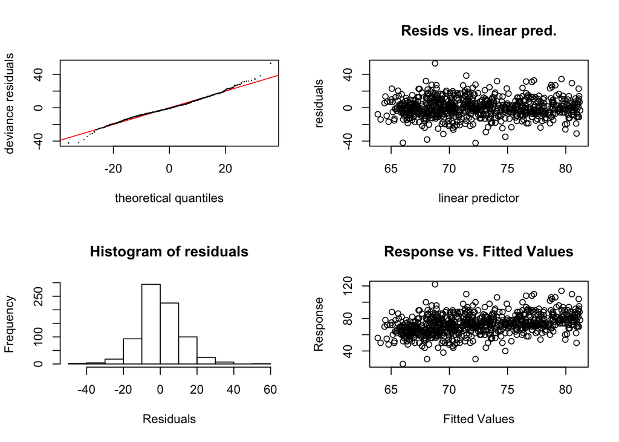

```
##
## Method: GCV   Optimizer: magic
## Smoothing parameter selection converged after 12 iterations.
## The RMS GCV score gradient at convergence was 1.109041e-05 .
## The Hessian was positive definite.
## Model rank =  29 / 29
##
## Basis dimension (k) checking results. Low p-value (k-index<1) may
## indicate that k is too low, especially if edf is close to k'.
##
##               k'   edf k-index p-value
## s(glucose) 9.000 2.313   1.036    0.84
## s(insulin) 9.000 1.000   0.993    0.40
## s(age)     9.000 2.413   0.992    0.37
```

```r
# view summary output
gam.check(gam1)
```

```r
names(gam1)
```

```
##  [1] "coefficients"      "residuals"         "fitted.values"
##  [4] "family"            "linear.predictors" "deviance"
##  [7] "null.deviance"     "iter"              "weights"
## [10] "prior.weights"     "df.null"           "y"
## [13] "converged"         "sig2"              "edf"
## [16] "edf1"              "hat"               "R"
## [19] "boundary"          "sp"                "nsdf"
## [22] "Ve"                "Vp"                "rV"
## [25] "mgcv.conv"         "gcv.ubre"          "aic"
## [28] "rank"              "gcv.ubre.dev"      "scale.estimated"
## [31] "method"            "smooth"            "formula"
## [34] "var.summary"       "cmX"               "model"
## [37] "control"           "terms"             "pred.formula"
## [40] "pterms"            "assign"            "xlevels"
## [43] "offset"            "df.residual"       "min.edf"
## [46] "optimizer"         "call"
```

```r
gam1$aic
```

```
## [1] 5904.123
```

```r
gam1$sig2
```

```
## [1] 126.1119
```

Play with some basic plotting features

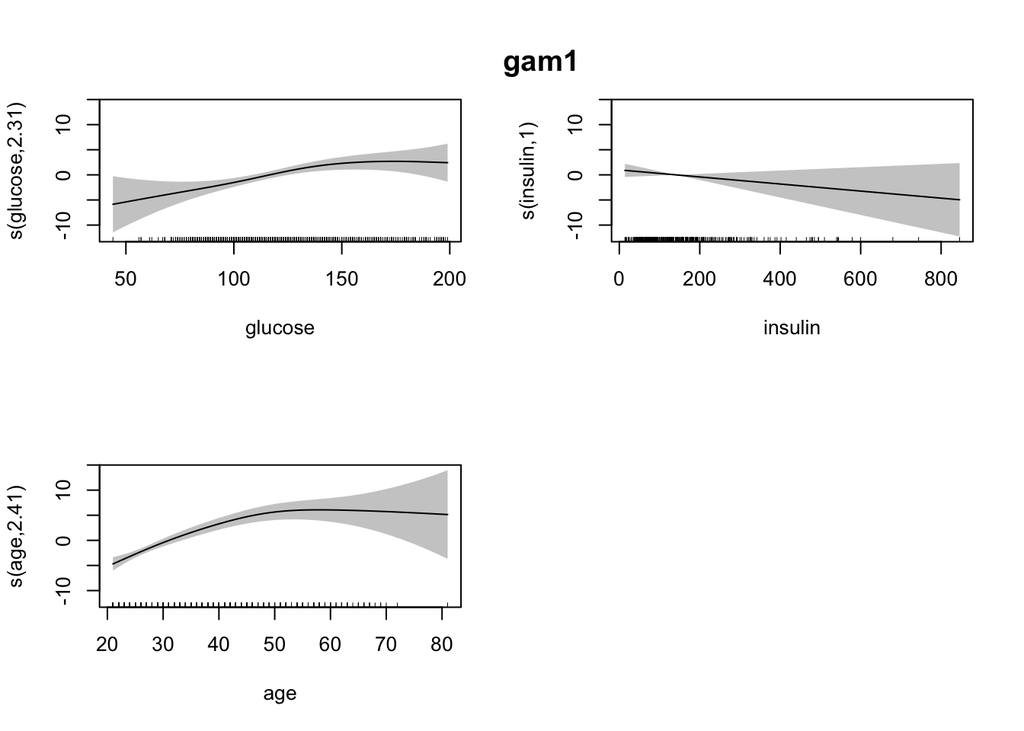

```r
plot(gam1, se=T,
         shade=T, col="black", shade.col="gray80",
         residuals=F,
         pages=1)
title("gam1")
```

## 5. Compare the GAM to other similar GAMs!

Our plots suggest that “glucose” is fairly linear. What if we compare `gam1` to two other GAMs - one that *excludes* the predictor glucose, and another that *assumes a linear relationship* of glucose?

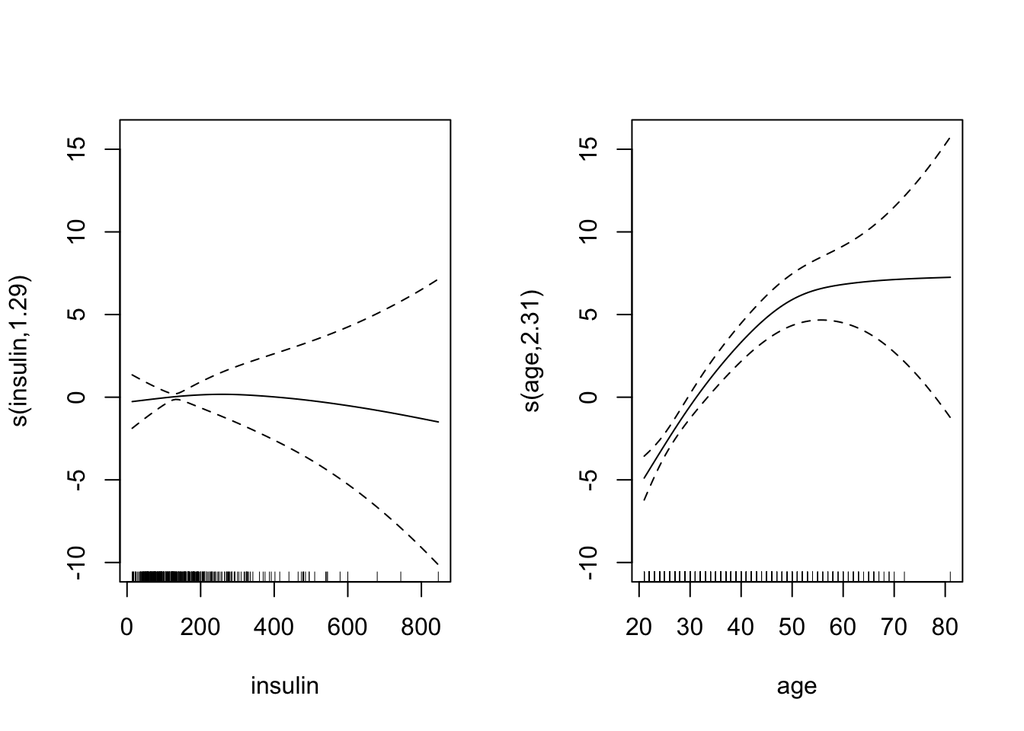

```r
# model that excludes glucose
gam2 <- gam(pressure ~ s(insulin) + s(age) + diabetes,
            family="gaussian",
            method="GCV.Cp",
            data=data)

plot(gam2, pages=1)
```

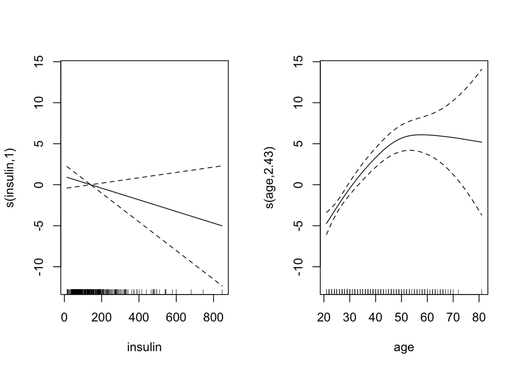

```r
# model that assumes linear glucose
gam3 <- gam(pressure ~ glucose + s(insulin) + s(age) + diabetes,
            family="gaussian",
            method="GCV.Cp",
            data=data)

plot(gam3, pages=1)
```

```r
anova(gam1, gam2, gam3, test="F") # small p-value suggests that a non-linear function for glucose is preferable?
```

```
## Analysis of Deviance Table
##
## Model 1: pressure ~ s(glucose) + s(insulin) + s(age) + diabetes
## Model 2: pressure ~ s(insulin) + s(age) + diabetes
## Model 3: pressure ~ glucose + s(insulin) + s(age) + diabetes
##   Resid. Df Resid. Dev       Df Deviance       F    Pr(>F)
## 1    759.04      95880
## 2    761.57      98098 -2.52839  -2218.4  6.9572 0.0003364 ***
## 3    760.94      96453  0.62785   1645.4 20.7813 0.0001390 ***
## ---
## Signif. codes:  0 '***' 0.001 '**' 0.01 '*' 0.05 '.' 0.1 ' ' 1
```

```r
AIC(gam1, gam2, gam3) # is this a multiple comparison problem?
```

```
##            df      AIC
## gam1 8.725948 5904.123
## gam2 6.594223 5917.426
## gam3 7.430271 5906.107
```

```r
BIC(gam1, gam2, gam3)
```

```
##            df      BIC
## gam1 8.725948 5944.644
## gam2 6.594223 5948.048
## gam3 7.430271 5940.612
```

What if we want to identify unhelpful predictors and remove them for better results?

```r
table(data$diabetes, I(data$pregnant>14))
```

```
##
##     FALSE TRUE
##   0   500    0
##   1   266    2
```

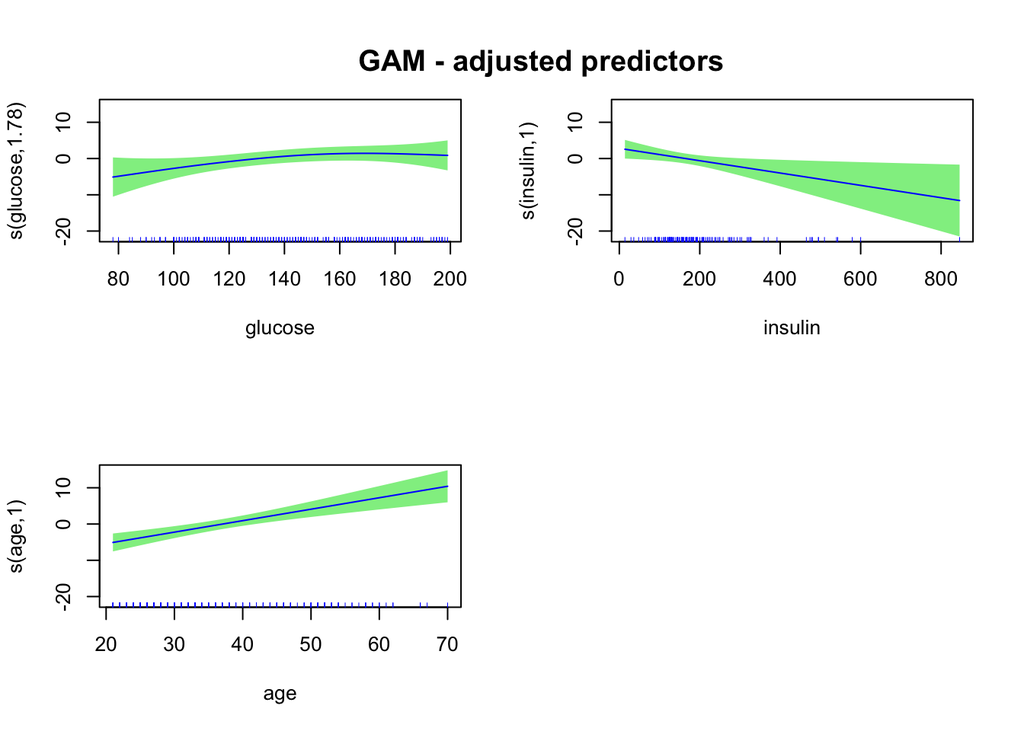

```r
gam4 <- gam(pressure ~ s(glucose) + s(insulin) + s(age) + diabetes,
            family="gaussian",
            data=data,
            subset=(diabetes !=0))

plot(gam4, se=TRUE, seWithMean=TRUE,
         shade=TRUE, col="blue", shade.col="lightgreen",
         residuals=FALSE,
         pages=1)
title("GAM - adjusted predictors")
```

```r
AIC(gam1, gam2, gam3, gam4)
```

```
##            df      AIC
## gam1 8.725948 5904.123
## gam2 6.594223 5917.426
## gam3 7.430271 5906.107
## gam4 5.777994 2067.410
```

## 6. plotmo

The “plotmo” R package offers a great way to visualize regression splines in three dimensions:

```
##  plotmo grid:    diabetes glucose insulin age
##                         0     117     125  29
```

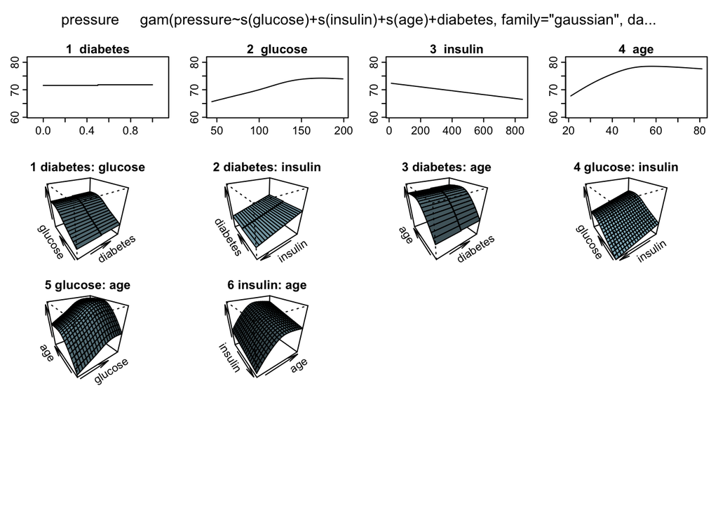

```r
plotmo(gam1, all2=TRUE) # show simplfied seWithMean plots AND three dimensional splines for all variable relationships
```

```
## calculating apartdep for diabetes
## calculating apartdep for glucose
## calculating apartdep for insulin
## calculating apartdep for age
## calculating apartdep for diabetes:glucose 0123456790
## calculating apartdep for diabetes:insulin 0123456790
## calculating apartdep for diabetes:age 0123456790
## calculating apartdep for glucose:insulin 01234567890
## calculating apartdep for glucose:age 01234567890
## calculating apartdep for insulin:age 01234567890
```

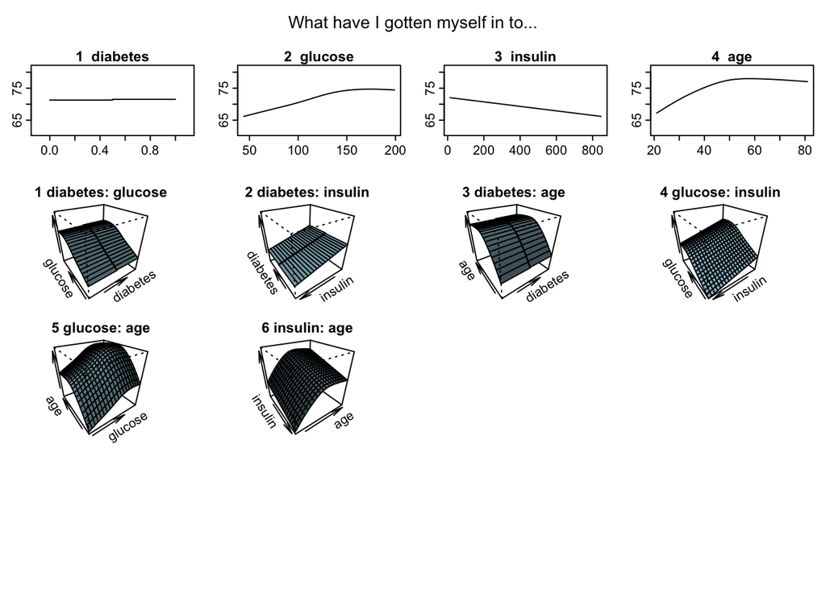

```r
# non-additive shapes have correlated effects in 3D plane surfaces.

# plot partial dependencies (takes a few minutes)
# plotmo(gam1, all2=TRUE, pmethod = "partdep")

# faster version of pmethod="partdep"
plotmo(gam1, all2=TRUE, pmethod = "apartdep",
       caption = "What have I gotten myself in to...")
```

```
##  plotmo grid:    diabetes glucose insulin age
##                         0     117     125  29
```

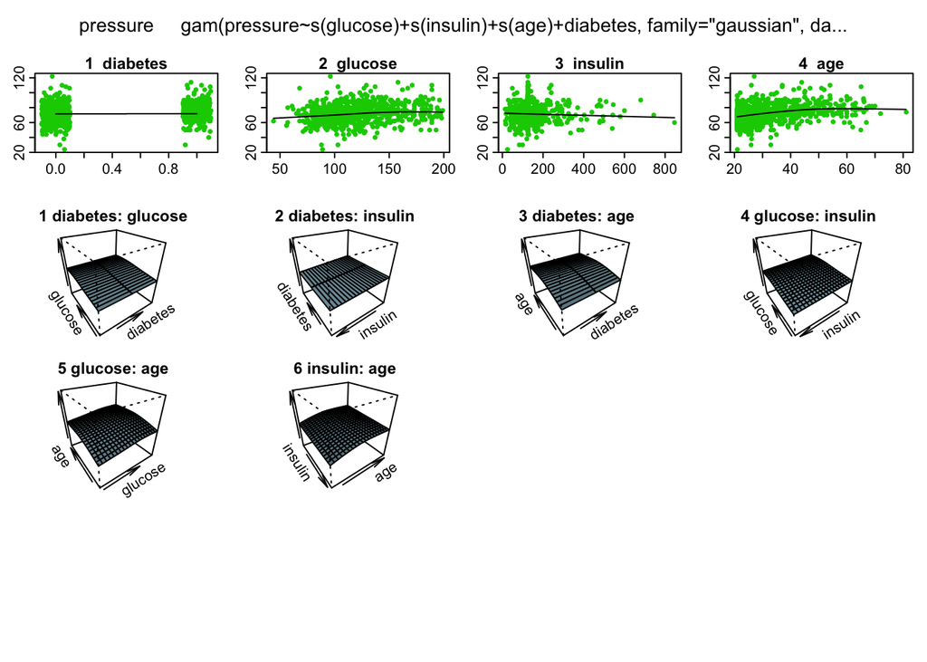

```r
# let's play around with a few more parameters!
plotmo(gam1, all2=TRUE, pt.col = "green3")
```